# Parallel models: training many parallel models for hierarchical time series optimization

Vanja Paunic

13 March, 2017

## 0.1 Hierarchical time series

Time series data can often be disaggregated by attributes of interest to form groups of time series or a hierarchy. For example, one might be interested in forecasting demand of all products in total, by location, by product category, by customer, etc. (see picture below). Forecasting hierarchical time series data is challenging because the generated forecasts need to satisfy the aggregate requirement, that is, lower-level forecasts need to sum up to the higher-level forecasts. There are many approaches that solve this problem, differing in the way they aggregate individual time series forecasts across the groups or the hierarchy: bottom-up, top-down, or middle-out.

Training hierarchical time series forecasting models require searching through a large parameter space. The model’s performance greatly varies over the parameters we choose, some of which are:

- univariate time series method for individual series prediction
- method for reconciling forecasts across hierarchy
- weights we use to reconcile forecasts across hierarchy
- etc.

In this tutorial, we will use Australian tourism data set from ‘fpp’ package as a sample data set.

Rob J Hyndman (2013). fpp: Data for “Forecasting: principles and practice”. R package version 0.5. https://CRAN.R-project.org/package=fpp

- In total
- By state
- By city

This data can be represented as a hierarchy, as shown in the following picture:

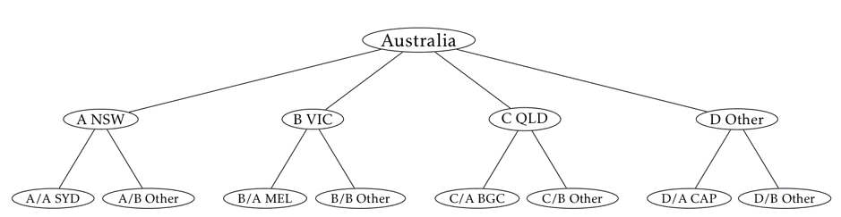

Australia tourism data set

## 0.2 Outline

In this tutorial we will:

1. create a hierarchical time series
2. split the data into training and testing
3. generate a grid of input parameters for forecasting function
4. call rxExec() to run forecasting over the parameter space distributed accross local cores or cluster nodes
5. find optimal parameters based on all runs
6. forecast the next two years using the optimal parameters
7. try running the above for larger data size

## 0.3 HTS Forecasting

### 0.3.1 Loading necessary libraries

```r
if(!require("hts")) install.packages('hts')
if(!require("fpp")) install.packages('fpp')

library(hts)
library(fpp)
```

### 0.3.2 Forecasting function

We will use the following function for time series forecasting. The function runs hierarchical forecast on training data set and returns evaluation metrics on test data set

```r
forecast_hts <- function (traindata, testdata, htsmethod, tsmethod, combweights){

  # Forecasting horizon
  horiz =  dim(aggts(testdata))[1]

  # Run hierarchical forecast
  hts_fcast <- forecast(object  = traindata,
                        h       = horiz,
                        method  = htsmethod,
                        fmethod = tsmethod,
                        weights = combweights)

  # Return evaluation metrics at the top level
  fcast_acc <- accuracy.gts(hts_fcast, test = testdata, levels = 0)

}
```

### 0.3.3 Hierarchical time series data set

Let’s process the data

```r
# Create hierachical time series dataset
htsdata <- hts(vn, nodes=list(4,c(2,2,2,2)))
```

```
## Since argument characters are not specified, the default labelling system is used.
```

```r
# Rename the nodes of the hierarchy
htsdata$labels$`Level 1` <- c("NSW", "VIC", "QLD", "Other")
htsdata$labels$`Level 2` <- c("Sydney", "NSW-Other", "Melbourne", "VIC-Other", "BrisbaneGC", "QLD-Other", "Capitals", "Other")
names(htsdata$labels) <- c("Total", "State", "City")

# Let's look at the data
htsdata
```

```
## Hierarchical Time Series
## 3 Levels
## Number of nodes at each level: 1 4 8
## Total number of series: 13
## Number of observations per series: 56
## Top level series:
##       Qtr1  Qtr2  Qtr3  Qtr4
## 1998 84502 65314 72749 70891
## 1999 86891 66872 72179 68323
## 2000 85650 64467 70408 72859
## 2001 80389 67973 69836 71446
## 2002 83932 63526 75548 75651
## 2003 83863 67191 71395 71662
## 2004 85838 66979 73837 70224
## 2005 85994 59635 66840 63390
## 2006 82646 67520 65944 69550
## 2007 86241 67397 69512 69204
## 2008 87012 59762 66413 64678
## 2009 74378 57936 65403 64519
## 2010 74635 59704 67534 63521
## 2011 72274 62906 70499 64894
```

```r
# Split data into train and test (leave out years 2010 and 2011 for testing)
train_data <- window(htsdata,  end = c(2009, 4))
test_data <- window(htsdata, start = c(2010, 1))
```

### 0.3.4 Visualizing hierarchy

Let’s see what the hierarchical time series data looks like.

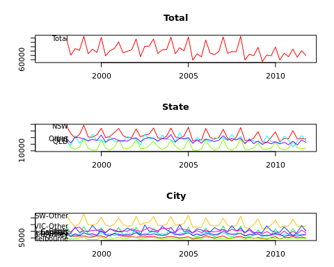

```r
# Plot the hierarchial time series data
plot(htsdata)
```

### 0.3.5 Parameter space

Let’s generate the parameter space

```r
# Vary methods for generating base time series forecasts
ts_method <- c("ets", "arima", "rw")

# Vary methods for reconciling base forecasts to satisfy aggregation requirement
hts_method <- c("bu", "comb", "tdgsa", "tdgsf", "tdfp")

# Vary forecast weights for the optimal cobination approach
comb_weights <- c("mint", "wls", "ols", "nseries")

# Generate all possible combinations of the above parameters
param_space <- expand.grid(hts_method, ts_method, comb_weights, stringsAsFactors = FALSE)
colnames(param_space) <- c("hts_method", "ts_method", "comb_weights")


# Remove ilegal combinations

#   - comb_weights only applies to hts_method == "comb"
rm_inds <- param_space$hts_method != "comb"
param_space$comb_weights[rm_inds] <- "none"
param_space <- param_space[!duplicated.data.frame(param_space),]
```

### 0.3.6 Compute contexts

Using Microsoft R Server’s *rxSetComputeContext()* function we can easily switch between different compute platforms, and run the same piece of code on those different platforms. *rxExec()* function then distributes the execution of the forecasting function we defined above onto the specified compute context.

- rxSetComputeContext(“local”) - sets compute context to “local” and causes rxExec() to execute runs locally in a serial manner.
- rxSetComputeContext(RxLocalParallel()) - causes rxExec() to run multiple tasks in parallel, thereby using the multiple cores on your local machine. The downside is that this will use more memory and will slow down your computer for other work you may be trying to do at the same time.
- rxSetComputeContext(RxSpark()) - for parallelized distributed execution via Spark across the nodes of a cluster

```r
rxSetComputeContext(RxSpark())
# rxSetComputeContext(RxSpark(consoleOutput=TRUE, numExecutors = 1, executorCores=2, executorMem="1g"))

# Measure execution time
et <- system.time(

# Run many distributed jobs
rxResult <- rxExec(FUN            = forecast_hts,
                   traindata      = train_data,
                   testdata       = test_data,
                   htsmethod      = rxElemArg(param_space$hts_method),
                   tsmethod       = rxElemArg(param_space$ts_method),
                   combweights    = rxElemArg(param_space$comb_weights),
                   consoleOutput  = TRUE,
                   packagesToLoad = c('hts'))
)
```

```
##  Running job: 59212
```

```r
cat(paste("Elapsed time: ", format(et['elapsed'], digits = 4), "seconds. \n"))
```

```
## Elapsed time:  63.6 seconds.
```

### 0.3.7 Gather the results

Collect the results of the rxExec(), and find the result with the best evaluation metric (smallest MAPE)

```r
all_mape <- sapply( rxResult, function(x) x["MAPE",] )
min_mape_indx <- which.min(all_mape)

# Optimal parameters
opt_params <- param_space[min_mape_indx,]

# Forecast the next 8 quarters using optimal parameters
horiz <- 8
hts_fcast <- forecast(object  = htsdata,
                      h       = horiz,
                      method  = opt_params$hts_method,
                      fmethod = opt_params$ts_method)
```

### 0.3.8 Print out the optimal results

```
## OPTIMAL RESULTS
##
##  Minimum obtained MAPE:  4.143
##  Optimal method for distributing forecasts within the hierarchy:  bu
##  Optimal forecasting method:  ets
```

```
##
##  Forecast for the next two years at the City level obtained using optimal parameters:
```

```
##           Sydney NSW-Other Melbourne VIC-Other BrisbaneGC QLD-Other
## 2012 Q1 5883.261  19675.56  5241.018 12657.614   8112.666  9622.465
## 2012 Q2 4938.497  13445.69  4374.214  7553.571   6495.615  9156.937
## 2012 Q3 5042.281  12918.31  4443.701  6307.109   7577.163 13429.576
## 2012 Q4 5485.261  14177.20  4768.798  7409.366   7275.824 10169.836
## 2013 Q1 5883.261  19675.56  5241.018 12657.615   8112.666  9622.465
## 2013 Q2 4938.497  13445.69  4374.214  7553.572   6495.615  9156.937
## 2013 Q3 5042.281  12918.31  4443.701  6307.110   7577.163 13429.576
## 2013 Q4 5485.261  14177.20  4768.798  7409.366   7275.824 10169.836
##         Capitals     Other
## 2012 Q1 8431.800  9919.774
## 2012 Q2 6950.333  8298.068
## 2012 Q3 7047.934 10687.761
## 2012 Q4 7043.002  8563.712
## 2013 Q1 8431.800  9926.172
## 2013 Q2 6950.333  8303.419
## 2013 Q3 7047.934 10694.654
## 2013 Q4 7043.002  8569.235
```

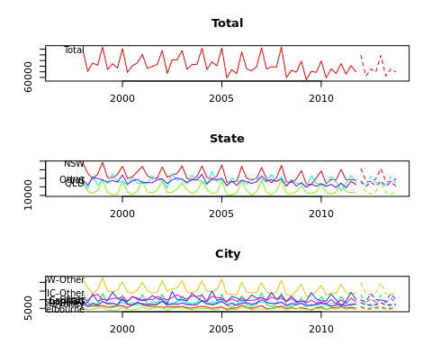

## 0.4 Hands-on exercise

In this part, we will try to run the above parameter sweep on a larger data set. Forecasting hierarchical time series takes more time for deeper and wider hierarchies, which are very common in real life applications. For example, if we were to forecast company sales by state, city, store, product category, and product, we would end up with hundreds of thousands of time series. Forecasting this time series hierarchy for just one parameter set may take hours. Doing a parameter sweep in such a scenario would be prohibitive. Being able to distribute that computation to a Spark cluster (by switching to *RxSpark()* compute context) with hundreds of cores reduces that time drastically.

Here, we will generate a larger time series data set. We will do that by replicating the existing data set, and adding a little bit of noise to it. To increase the data set we will multiply the number of time series with a factor *x*.

### 0.4.1 Generating larger data

```r
# Increase the number of time series by factor x
# TRY changing this variable
x = 5

# Function to add noise to a data set
addNoise <- function(data) {

  data_dim <- dim(data)[1] * dim(data)[2]
  noise <- matrix(runif(data_dim, -500, 500), dim(data)[1])
  noisified <- data + noise
  return(noisified)

}

# Replicate time series x times
larger_data <- coredata(vn)[ ,  rep(seq(ncol(vn)), x)]
larger_data <- addNoise(larger_data)

# Create a time series object
vnx <- ts(larger_data, frequency = 4, start = c(1998, 1))

# Create hierachical time series dataset
htsdata <- hts(vnx, nodes=list(4*x, rep(c(2,2,2,2), x)))
```

```
## Since argument characters are not specified, the default labelling system is used.
```

```r
# Let's see what our data looks like
print(htsdata)
```

```
## Hierarchical Time Series
## 3 Levels
## Number of nodes at each level: 1 20 40
## Total number of series: 61
## Number of observations per series: 56
## Top level series:
##          Qtr1     Qtr2     Qtr3     Qtr4
## 1998 422070.3 326537.6 366180.7 355943.7
## 1999 435820.2 329182.5 361440.4 339734.0
## 2000 427549.3 322386.6 353522.8 364062.0
## 2001 401738.8 339711.0 348391.3 356269.4
## 2002 420672.8 318184.3 378697.8 378502.7
## 2003 417755.1 333695.0 359748.2 358247.7
## 2004 428820.7 335062.4 365835.0 352580.6
## 2005 429109.4 298365.6 333427.7 315407.1
## 2006 410840.0 338402.2 332062.6 350052.8
## 2007 429248.6 335755.3 345557.6 348299.8
## 2008 431761.3 300996.6 328970.6 320320.2
## 2009 373946.7 294938.4 327345.1 320451.0
## 2010 374079.5 300747.2 337394.8 315849.5
## 2011 361359.8 315418.3 353514.5 325755.4
```

```r
# Rename the nodes of the hierarchy
htsdata$labels$`Level 1` <- paste0('State_', 1:length(htsdata$labels$`Level 1`))
htsdata$labels$`Level 2` <- paste0('City_', 1:length(htsdata$labels$`Level 2`))
names(htsdata$labels) <- c("Total", "State", "City")

# Split data into train and test (leave out years 2010 and 2011 for testing)
train_data <- window(htsdata,  end = c(2009, 4))
test_data <- window(htsdata, start = c(2010, 1))


# TRY changing the compute context and see how it affects the execution time
# rxSetComputeContext(RxLocalParallel())
rxSetComputeContext(RxSpark(consoleOutput = TRUE))

# Measure execution time
et <- system.time(

  # Run many distributed jobs
  rxResult <- rxExec(FUN            = forecast_hts,
                     traindata      = train_data,
                     testdata       = test_data,
                     htsmethod      = rxElemArg(param_space$hts_method),
                     tsmethod       = rxElemArg(param_space$ts_method),
                     combweights    = rxElemArg(param_space$comb_weights),
                     consoleOutput  = TRUE,
                     packagesToLoad = c('hts'))
)
```

```
##  Running job: 61406
```

```r
cat(paste("Elapsed time: ", format(et['elapsed'], digits = 4), "seconds. \n"))
```

```
## Elapsed time:  88.54 seconds.
```

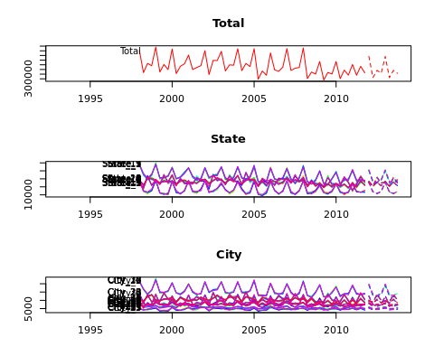

```r
all_mape <- sapply( rxResult, function(x) x["MAPE",] )
min_mape_indx <- which.min(all_mape)

# Optimal parameters
opt_params <- param_space[min_mape_indx,]

# Forecast the next 8 quarters using optimal parameters
horiz <- 8
hts_fcast <- forecast(object  = htsdata,
                      h       = horiz,
                      method  = opt_params$hts_method,
                      fmethod = opt_params$ts_method)

plot(hts_fcast)
```